# 判断根结点是否等于子结点之和

给你一个 二叉树 的根结点 root，该二叉树由恰好 3 个结点组成：根结点、左子结点和右子结点。

如果根结点值等于两个子结点值之和，返回 true ，否则返回 false 。

示例 1：

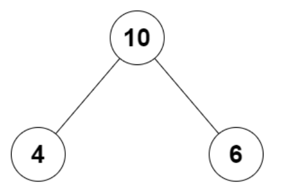

输入：root = [10,4,6] 输出：true 解释：根结点、左子结点和右子结点的值分别是 10 、4 和 6 。 由于 10 等于 4 + 6 ，因此返回 true 。 示例 2：

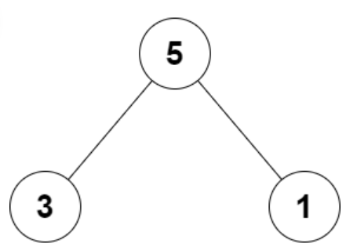

输入：root = [5,3,1] 输出：false 解释：根结点、左子结点和右子结点的值分别是 5 、3 和 1 。 由于 5 不等于 3 + 1 ，因此返回 false 。

提示：

树只包含根结点、左子结点和右子结点 -100 <= Node.val <= 100

来源：力扣（LeetCode） 链接：https://leetcode.cn/problems/root-equals-sum-of-children 著作权归领扣网络所有。商业转载请联系官方授权，非商业转载请注明出处。

```python
# Definition for a binary tree node.
# class TreeNode:
#     def __init__(self, val=0, left=None, right=None):
#         self.val = val
#         self.left = left
#         self.right = right
class Solution:
    def checkTree(self, root: Optional[TreeNode]) -> bool:
```

以上是题目内容，从注释中可知，二叉树的某个节点的左右子节点定义为self.left和self.right。

故可求解如下

```python
# Definition for a binary tree node.
from typing import Optional
class TreeNode:
    def __init__(self, val=0, left=None, right=None):
        self.val = val
        self.left = left
        self.right = right
class Solution:
    def checkTree(self,root: Optional[TreeNode]) -> bool:
        return root.val == root.right.val + root.left.val

root = TreeNode(10,TreeNode(4),TreeNode(6))

ss = Solution()
ss.checkTree(root)
```

```
True
```

第一个TreeNode只定义一个节点，.val是这个节点本身的值，.left和.right是这个点对应的左右子节点。

root = TreeNode(10,TreeNode(4),TreeNode(6)) 这里调用了三次TreeNode实例化，最外面的是根节点，值为10，左子节点为4，右子节点为6，第二次实例化就是对左子节点4实例化，这里只传了一个参数4，没传4的左右子节点故为空，同理右子节点6也是这样

调用checkTree函数时候，不可直接Solution.checkTree()，因为此时Solution类还未实例化。故应该先对其实例化，再调用其中的函数。

```python
print(root.left.left)#左子节点没有左子节点，故为None
print(root.left.right)#左子节点没有右子节点，故为None
```

```
None
None
```